# Quantiful Submission

Louis Lin

20/08/2019

<sub><sup>**NB**: this document is produced as an html file for aesthetic purposes and includes both the report and code for cohesiveness. I apologise if this is over 8 pages long.</sup></sub>

## Task 1

The initial read-in data is stored in `raw`:

```r
raw <- read_csv("ufo.csv")
```

```
## # A tibble: 6 x 16
##   datetime            date        year month day_of_week hour_of_day city
##   <dttm>              <date>     <dbl> <dbl> <chr>             <dbl> <chr>
## 1 1949-10-10 08:30:00 1949-10-10  1949    10 Mon                  20 san ~
## 2 1949-10-10 09:00:00 1949-10-10  1949    10 Mon                  21 lack~
## 3 1955-10-10 05:00:00 1955-10-10  1955    10 Mon                  17 ches~
## 4 1956-10-10 09:00:00 1956-10-10  1956    10 Wed                  21 edna
## 5 1960-10-10 08:00:00 1960-10-10  1960    10 Mon                  20 kane~
## 6 1961-10-10 07:00:00 1961-10-10  1961    10 Tues                 19 bris~
## # ... with 9 more variables: shape <chr>, duration <dbl>,
## #   duration_pretty <chr>, latitude <dbl>, longitude <dbl>,
## #   comments <chr>, country_clean <chr>, continent <chr>, iso <chr>
```

Due to the length of `summary(raw)` I have elected to exclude it from this report, but it was used to check for extreme or unusual data. The data contains `NA` values which we will clean later.

```r
summary(raw)
```

## Tasks 2 and 3

### Number of sightings by year and continent

We first group the raw data by `year` and `continent`, then sum the sightings accordingly. Observations are dropped if the row contains any `NA` values.

```r
yr_cont <- raw %>%
  group_by(year,continent) %>%
  dplyr::summarise(count=n())  %>%
  drop_na(colnames(~.))
```

Figure 1 below illustrates the result.

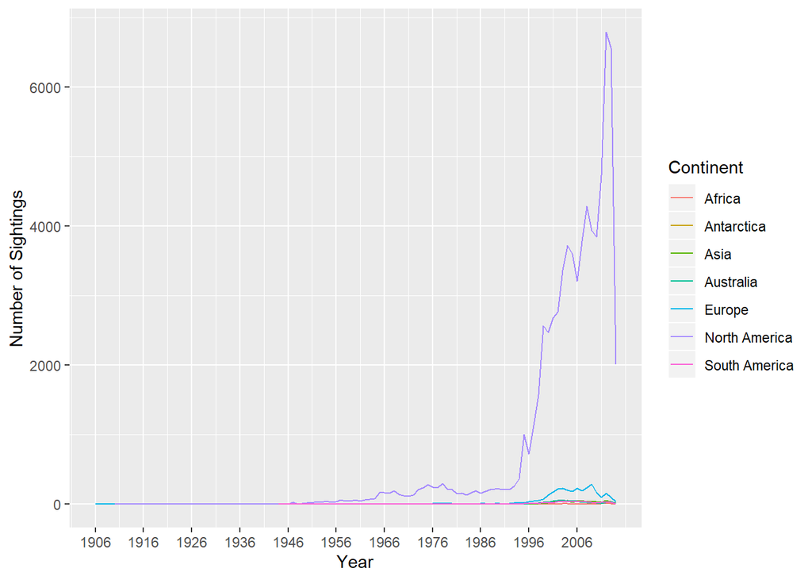

**Figure 1**: Number of UFO sightings by year and continent.

In Figure 1, we observe that North Americans have reported significantly more UFO sightings than any other continent. As to why this is the case, I hypothesise that North America, being the land of the free, have always been vocal about their thoughts. Given the American Government’s rather spotted history with their *secret* UFO program and the infamous notion that the government is hiding something from its people, North Americans have more reason to believe what they allegedly see. Moreover, their belief is fuelled further by their own Navy pilots reporting such cases, and so the theory is that we see what we believe so there is an intrinsic bias toward reporting sightings.

Given North America’s overwhelming statistics, we exclude it in Figure 2 below to give us a better perspective of sightings from the other continents.

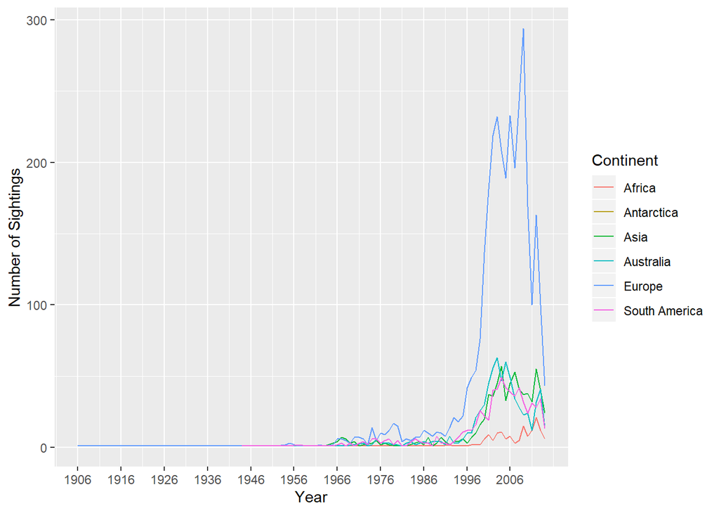

**Figure 2**: Number of UFO sightings by year and continent excluding North America.

I would theorise that the recent decline in sightings may be due to a societal awareness of false information. Modern technology has allowed us to manipulate images and information easier than ever, and this has resulted in a tendency to be more critical of what we read and hear. And if the laugh reacts on FaceBook UFO posts are any indication of our beliefs, then the fall in UFO sightings are nothing but expected.

### Number of sightings by hour of day

We apply the same method as above to generate Figures 3 to 5.

```r
hr <- raw %>%
  group_by(hour_of_day) %>%
  dplyr::summarise(count=n())  %>%
  drop_na(colnames(~.)) %>%
  filter(hour_of_day %in% c(0:23))
```

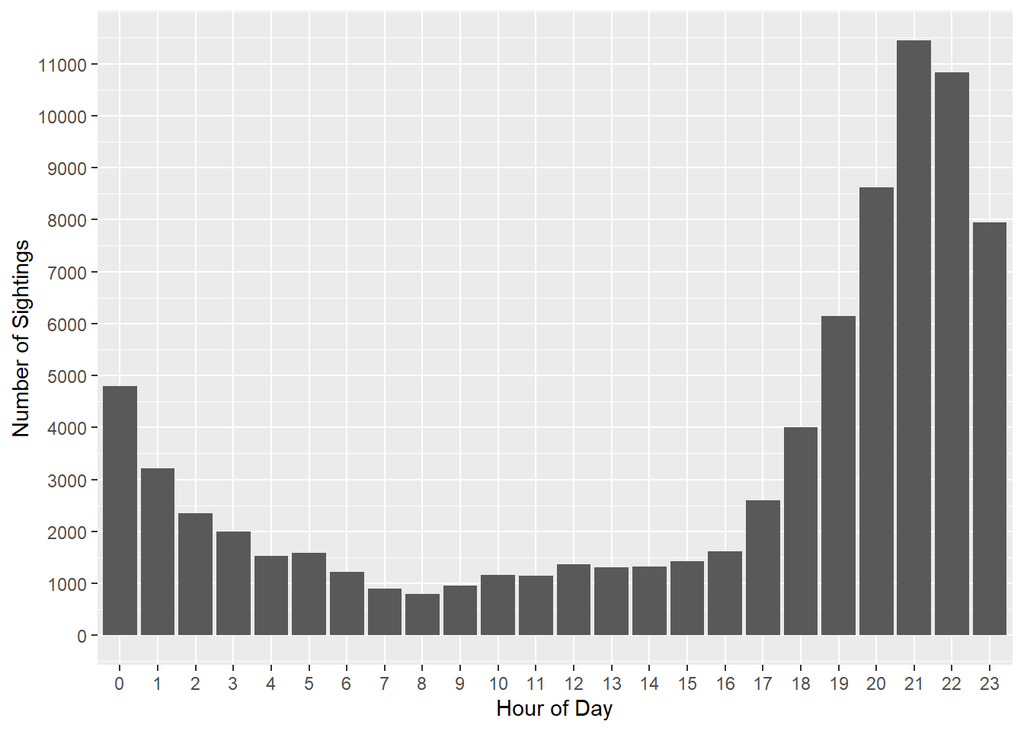

**Figure 3**: Number of UFO sightings by hour of day worldwide.

Assuming all sightings were reported using relative timezones, it is no surprised that the majority of reports are during the night. During the day, flying objects are more identifiable, such as planes and helicopters. At night, it is difficult to distinguish between an aircraft and a UFO. In Figure 3, from 00:00 to 08:00, we see a decline in sightings as less people are awake so proportionally speaking there should be less reports. From 08:00 to 16:00, sightings increase but marginally probably as most people are still at work or in school and have not had an opportunity to look at the sky. As the populations begin to leave school or get off work and have the freedom to observe the skies, there is an increase in sightings. Coupled with poor visibility and tiredness from the day, it is self-explanatory why sightings drastically increase and peak at 21:00. Then as people head to bed, reports dwindle once more.

### Number of sightings by month

```r
mth <- raw %>%
  group_by(month) %>%
  dplyr::summarise(count=n())  %>%
  drop_na(colnames(~.)) %>%
  filter(month %in% c(1:12))
```

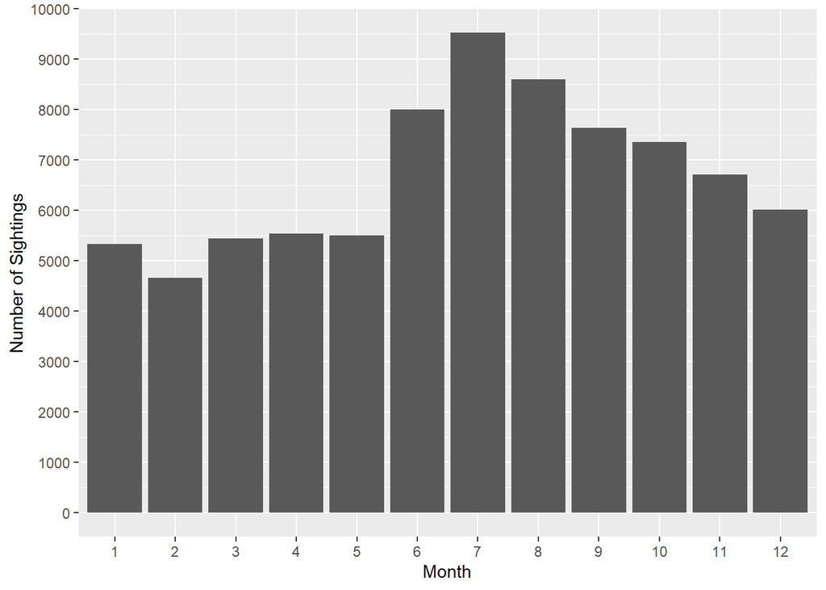

**Figure 4**: Number of UFO sightings by month worldwide.

As we saw in Figure 1, a very significant proportion of total sightings are from North America. In Figure 2, the second most sightings was observed to be Europe. Thus, it stands to reason that June, July, and August, the three months of summer in the northern hemisphere, have the most reported UFO sightings. In general, people are outdoors more during the day and night in summer and Figure 4 is congruent with this theory.

### Number of sightings by day of week

The `ordered` function is used to produce a plot in chronological order.

```r
day <- raw %>%
  group_by(day_of_week) %>%
  dplyr::summarise(count=n())  %>%
  drop_na(colnames(~.))

day$day_of_week <- ordered(day$day_of_week,levels=c("Mon","Tues","Wed","Thurs","Fri","Sat","Sun"))
```

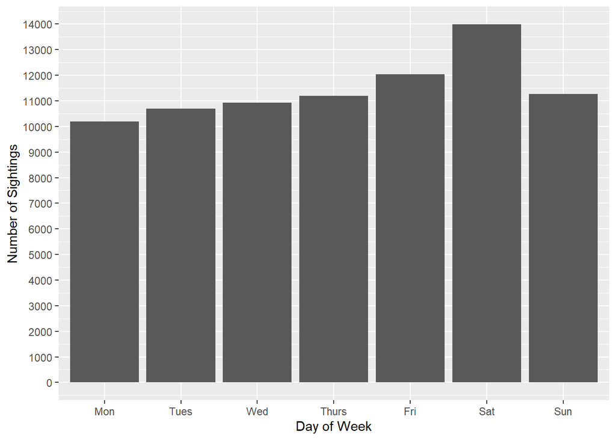

**Figure 5**: Number of UFO sightings by day of week worldwide.

We have two theories thus far: (1) Sightings are more common at night and (2) sightings are more common when people are outdoors. In correspondance with Figure 5 above, this leads me to believe that Saturdays have the most reports as more people are outdoors on Saturday nights. Comparatively, fewer people will be out on a Sunday night (due to work the following morning), so there are fewer reports, but still more than Monday through to Thursday when fewer people will be outdoors both during the day and night. Fridays have more reportings than Sundays, again, perhaps due to more people being out during Friday night.

### Top 10 most popular UFO shapes

We proceed to group observations by `shape` and order by frequency, then use `slice` function to filter the top 10.

```r
top_shape <- raw %>%
  group_by(shape) %>%
  dplyr::summarise(count=n()) %>%
  arrange(desc(count)) %>%
  slice(1:10)
```

We apply the `factor` function to produce a nicer plot (maintain plotting order).

```r
top_shape$shape <- factor(top_shape$shape, levels=unique(top_shape$shape))
```

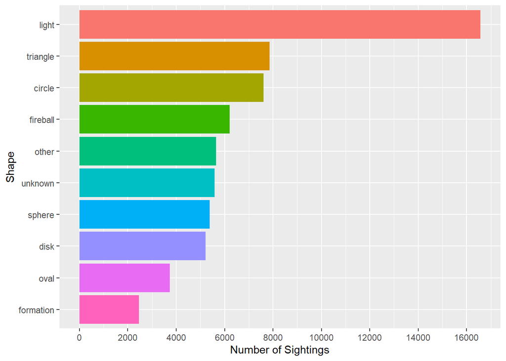

**Figure 6**: Top 10 most popular shapes of reported UFO sightings.

From Figure 6, we see that `light` is, by far, the most commonly reported shape. Although I would disagree that light is a shape, the point is that at night, when UFO’s are more often reported, the only way of seeing anything is if it is emitting light. It stands to reason that this is the case for these results.

`circle`, `sphere`, `disk`, and `oval` are all geometrically similar in 2D plane (as is observed from the ground) and their appearance in the top 10 corresponds to popular depictions of ringed-dome-shaped extraterrestrial spacecrafts.

`triangle` is more commonly reported than suspected. My theory is that these were stealth aircrafts or triangular jets such as the Avro Vulcans. In fact, most commercial aircrafts use bright white anti-collision lights during cruise. These are located on wingtips and the tail and can be seen from the ground. This forms a triangle which can be misidentified as a UFO.

`fireball` is the fourth most reported shape; three possibilities are: (1) a realistic object entering the atmosphere (e.g. stage 1 of a rocket, meteor, satellite deorbit), (2) an aircraft crashing, or (3) a real UFO burning. The most likely is (1), in fact, many people reported SpaceX’s second stage burn as possible UFO sightings.

### Top 10 countries where UFOs were sighted most

The same method as above is applied to the top 10 countries with a few modifications for plotting and readibility purposes.

```r
top_ctry <- raw %>%
  dplyr::rename(ctry=country_clean) %>%
  group_by(ctry) %>%
  dplyr::summarise(count=n()) %>%
  arrange(desc(count)) %>%
  slice(1:10)

top_ctry$ctry[top_ctry$ctry=="United States of America"] <- "USA"
top_ctry$ctry[is.na(top_ctry$ctry)] <- "Unknown"

top_ctry$ctry <- factor(top_ctry$ctry, levels=unique(top_ctry$ctry))
```

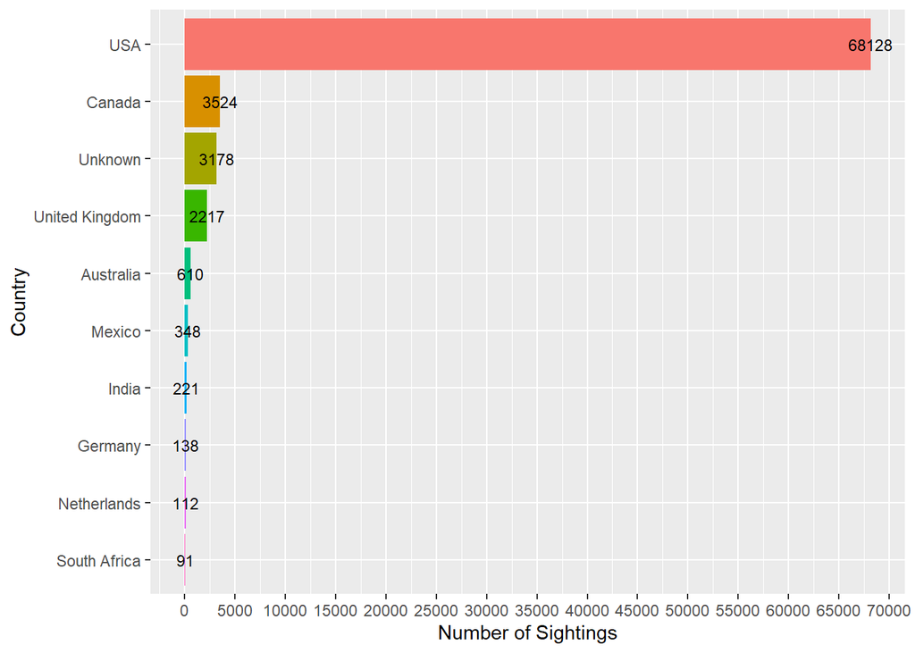

**Figure 7**: Top 10 most reported UFO sightings by country.

As seen in Figure 1, North America had the most reported sightings so it stands to reason that USA and Canada would have the most and second most reports. As discussed previously, the US Government have “leaked” involvements with UFO’s and the US population grow ever more concerned, believing that this must be the case. Canada comes in second due to their geopolitical ties with the US, including both geographical proximity and cultural similarities.

`Unknown` could be due to witnesses being unwilling to give away their location for privacy reasons. It may also be due to older data; perhaps older reports did not include a location field.

## Task 4

In the following code chunk, I’ve loaded the `tm`, `stringr`, and `tidytext` packages to help with string manipulation.

```r
library(tm)
library(stringr)
library(tidytext)

comment <- raw$comments %>%
  str_replace_all("&#44"," ") %>%
  tolower() %>%
  removePunctuation() %>%
  removeWords(stopwords("english")) %>%
  data.frame() %>%
  lapply(as.character)
```

As this tasks only requires the `comments` column, I’ve excluded the rest of the dataframe. I also piped the column through a `str_replace_all` function first. This reduces the runtime for `tolower` and eliminates `"44"` only if it is preceded by `"&#"`. If `removePunctuation` was run before `str_replace_all` with `"44"` then valid inputs of `"44"` may be discarded.

Stop words are removed and the output is transformed into a dataframe and converted to a column of type character.

Finally, the output is transformed into a term document matrix to perform frequency count and Figure 8 is produced.

```r
tdm <- Corpus(VectorSource(comment)) %>%
  TermDocumentMatrix() %>%
  as.matrix()

sort_tdm <- sort(rowSums(tdm),decreasing=TRUE)

word_freq <- data.frame(word = names(sort_tdm),freq=sort_tdm) %>%
  slice(1:10)

word_freq$word <- factor(word_freq$word, levels=unique(word_freq$word))
```

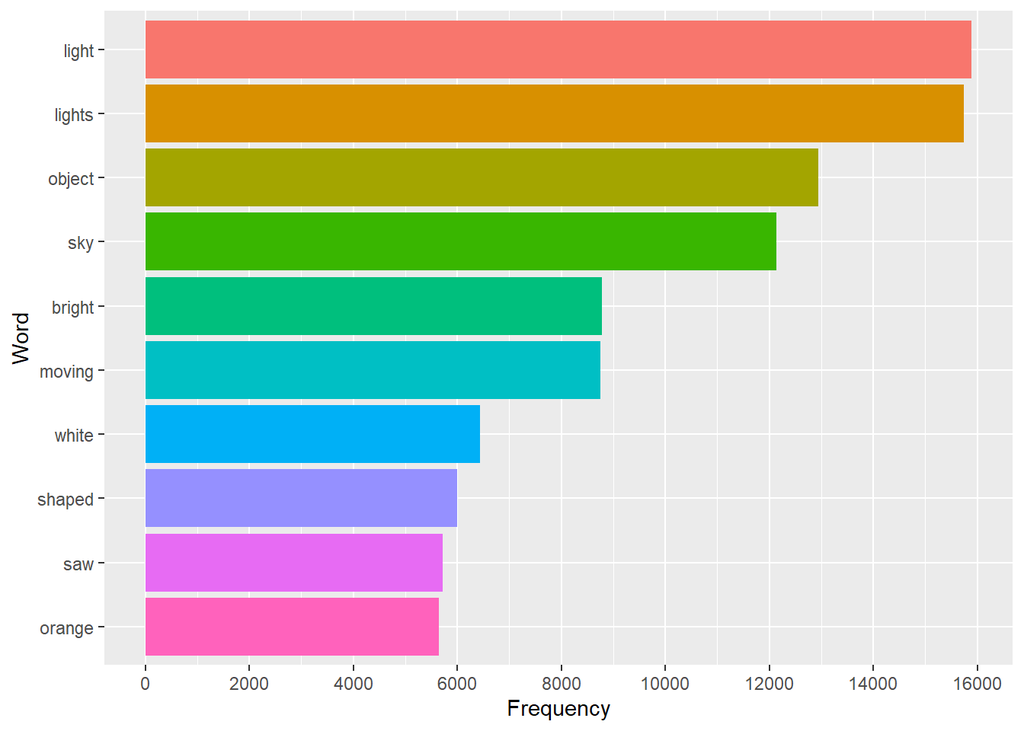

**Figure 8**: 10 most frequently used words in the `comments` column.

## Task 5

Let’s load `padr` and `lubridate` to help with manipulating time series data.

```r
library(padr)
library(lubridate)
```

The raw data does not contain incremental rows of dates so we proceed to pad it out using `padr`’s `pad` function. But first we pipe the raw data through a grouping by `date` and sum the number of sightings accordingly. A final `group_by` allows us to perform a summation by month.

```r
series_data <- raw %>%
  group_by(date) %>%
  dplyr::summarise(count=n()) %>%
  na.omit() %>%
  pad() %>%
  fill_by_value() %>%
  group_by(month=floor_date(date,"month")) %>%
  summarise(count=sum(count))
```

We then transform the data into a time series type data using `ts` to produce Figure 9.

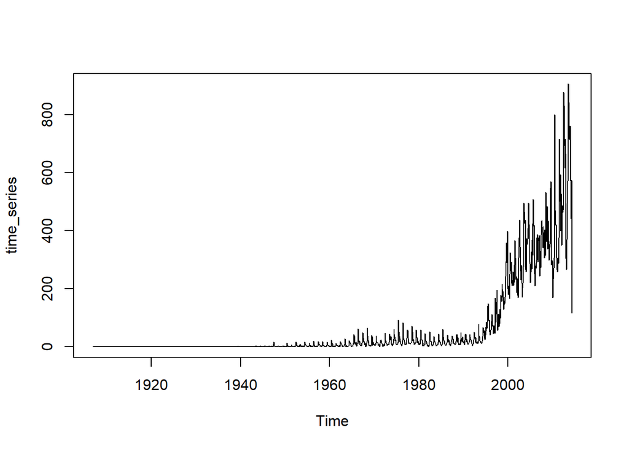

```r
time_series <- series_data$count %>% ts(frequency = 12, start=c(1906,11))

plot(time_series)
```

Figure 9 doesn’t look great as there’s very little activity in the 20th century compared to the 21st. Figure 10 below gives us a better idea of recent activity.

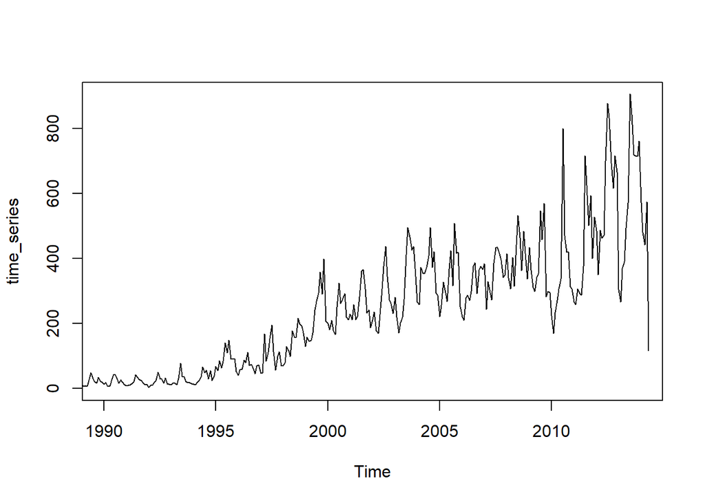

An additive model doesn’t look great for this time series so we’ll try log transforming the data.

```r
log_time_series <- log(time_series)
```

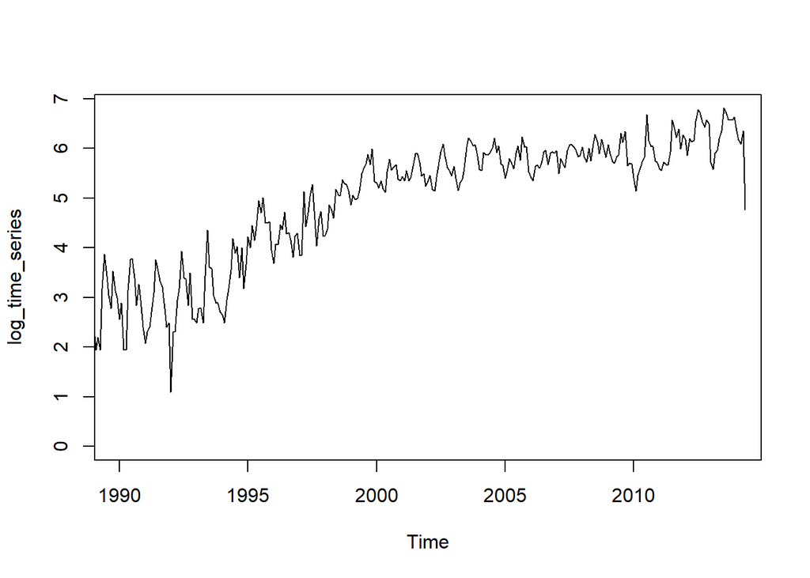

Figure 11 looks much better.

However, as our data contained values of 0, logging the time series has resulted in undefined values (namely `-Inf`). So we proceed to drop all observations prior to and including the most recent month with no observations.

```r
library(zoo)
log_time_series <- as.ts(tail(as.zoo(log_time_series), -max(which(log_time_series==-Inf))))
```

We can now decompose the time series to analyse its components.

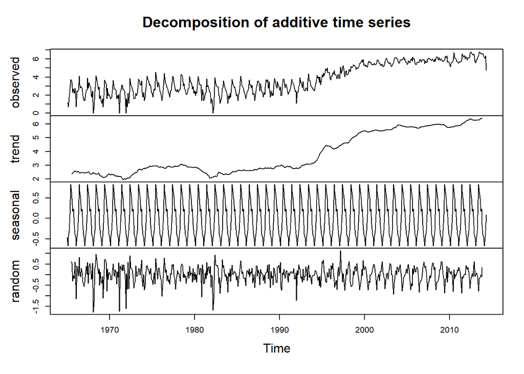

```r
decomposed <- decompose(log_time_series)
plot(decomposed)
```

Let’s now produce a one-year forecast. Our log-transformed time series has an increasing trend with seasonality so we’ll opt to fit the data with Holt-Winters exponential smoothing.

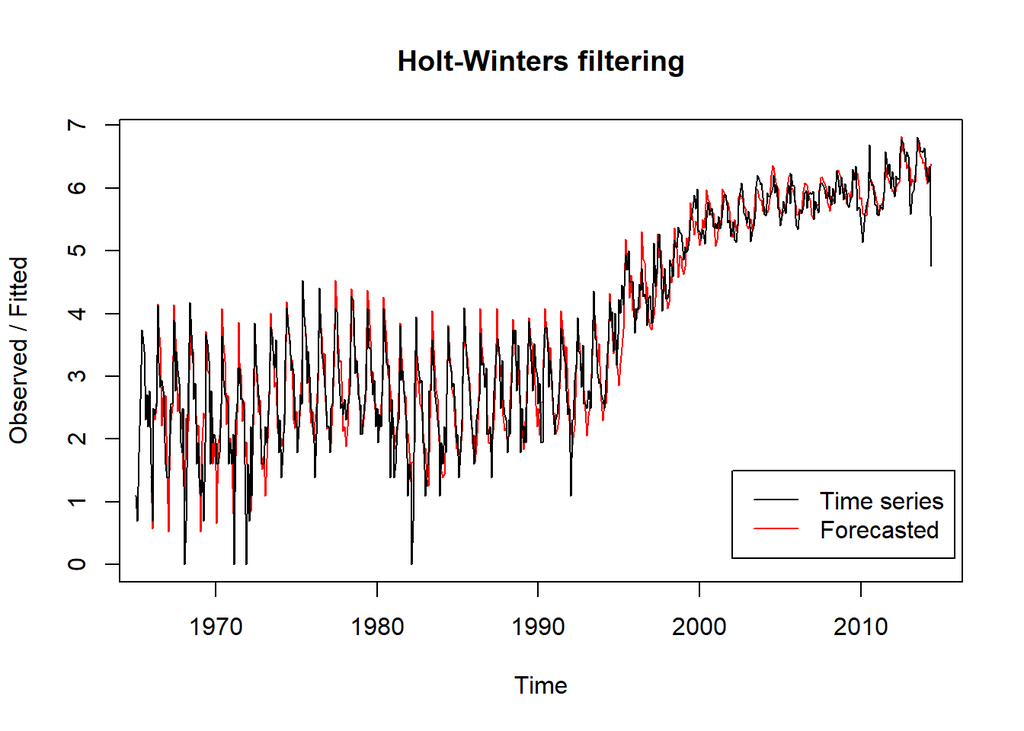

```r
ufo_fit <- HoltWinters(log_time_series)
plot(ufo_fit)
  legend(2002, 1.5, legend=c("Time series", "Forecasted"), lwd=c(1,1), col=c("black", "red"))
```

We see the forecast performs rather well; in particular, seasonal effects are captured with relatively good accuracy. We’ll use Holt-Winters to forecast sightings one year on.

```r
ufo_forecast <- forecast:::forecast.HoltWinters(ufo_fit, h=12)
```

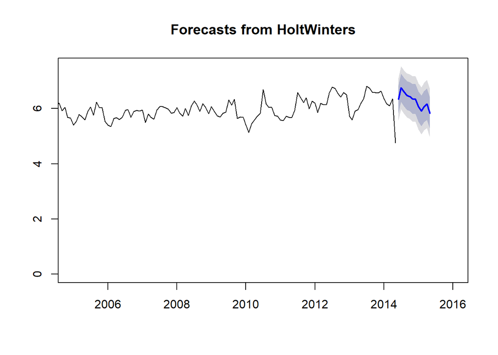

```r
forecast:::plot.forecast(ufo_forecast, xlim=c(2005,2016))
```

We’ll make a correlogram and carry out the Ljung-Box test to investigate our predictive model.

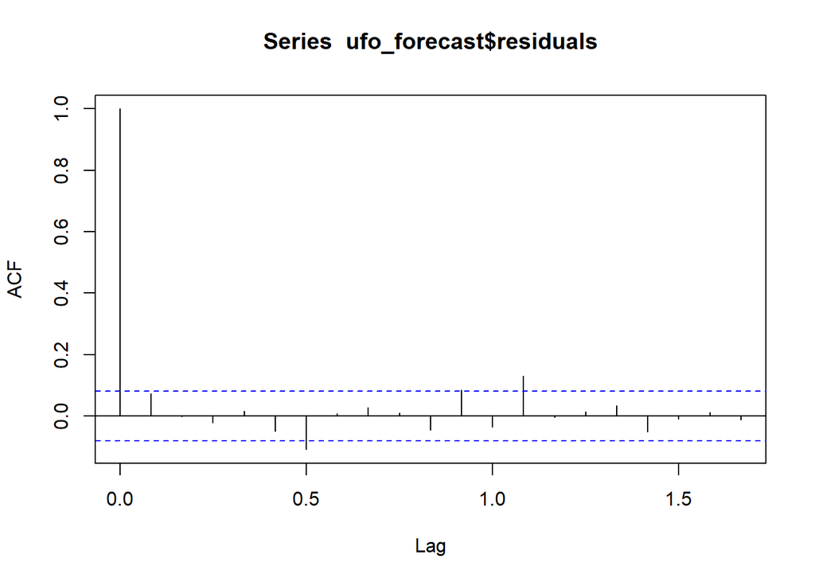

```r
acf(ufo_forecast$residuals, lag.max=20, na.action = na.pass)
```

```r
Box.test(ufo_forecast$residuals, lag=20, type="Ljung-Box",)
```

```
##
##  Box-Ljung test
##
## data:  ufo_forecast$residuals
## X-squared = 31.595, df = 20, p-value = 0.04781
```

The in-sample forecast errors are not all within the bounds for lags 1-20. Furthermore, the p-value from the Ljung-Box test is 0.047, which means there may be dependence between observations. This would make sense as earlier in this document, I theorised that sightings are heavily influence by trending cultures. It is likely that the frequency of reported sightings can have effects on subsequent reportings. Thus, we may need to use an ARIMA model to fit our time series.

Due to lack of time, I will ignorantly round the p-value up to 0.05 and proceed with the forecast.

We’ll now check if model assumptions are true.

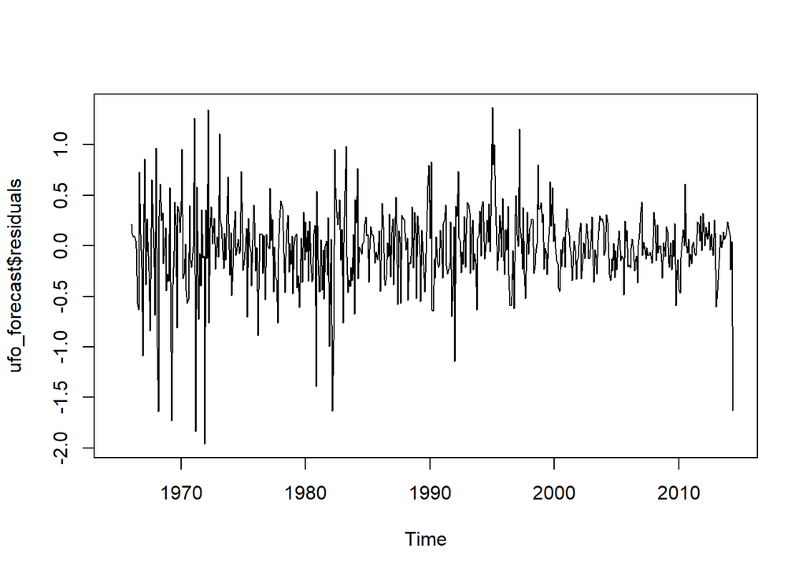

```r
plot.ts(ufo_forecast$residuals)
```

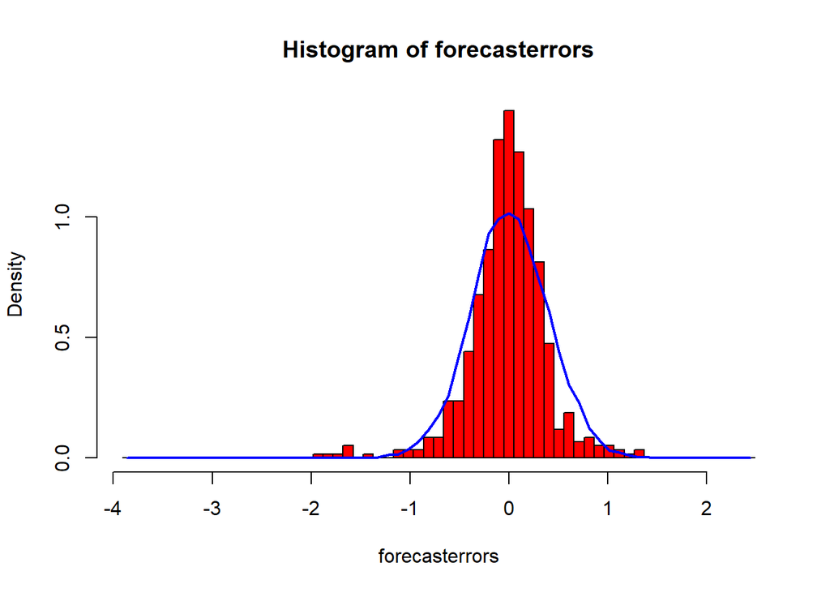

```r
plotForecastErrors(na.omit(ufo_forecast$residuals))
```

### Summary

In summary, we have autocorrelations exceeding lags 1-20 and our p-value also suggests that this may be the case. Our assumptions are not completely valid so there may be better predictors thatn Holt-Winters exponential smoothing for this time series.

## Works Cited

“Black Triangle.” RationalWiki, [rationalwiki.org/wiki/Black_triangle](https://en.wikipedia.org/wiki/Black_triangle).

Jaekl, Philip. “What Is behind the Decline in UFO Sightings?” *The Guardian*, Guardian News and Media, 21 Sept. 2018, www.theguardian.com/world/2018/sep/21/what-is-behind-the-decline-in-ufo-sightings.

Porter, Tom. “US Senators Reportedly Got a Classified Briefing on UFOs after Navy Pilots Reported Seeing Spherical Objects Flying at ‘Hypersonic Speed’.” *Business Insider Australia*, Business Insider Australia, 20 June 2019, www.businessinsider.com.au/senators-briefed-on-ufo-sightings-by-navy-pilots-report-2019-6?r=US&IR=T.

“Savvy Passenger Guide to Airplane Lights.” *AeroSavvy*, 8 Dec. 2017, aerosavvy.com/airplane-lights/.

“UFOs in Fiction.” *Wikipedia*, Wikimedia Foundation, 6 Aug. 2019, en.wikipedia.org/wiki/UFOs_in_fiction.

“Using R for Time Series Analysis¶.” *Using R for Time Series Analysis - Time Series 0.2 Documentation*, a-little-book-of-r-for-time-series.readthedocs.io/en/latest/src/timeseries.html.

[Louis C.F. Lin](https://github.com/LouiiL)

*louiscflin@gmail.com*